# Generate synthetic data

# Some Visualization of data

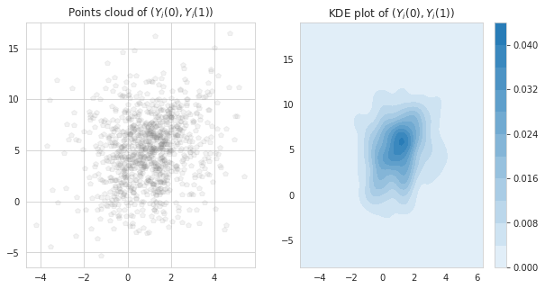

```python
# Viz of (Y(0),Y(1))
plt.figure(figsize = (10,5))
plt.subplot(121)
plt.plot(Y0_train[:1000],Y1_train[:1000],"p",alpha = 0.1, color = "grey")
plt.title("Points cloud of $(Y_i(0),Y_i(1))$")
plt.subplot(122)
sns.kdeplot(Y0_train[:1000],Y1_train[:1000],shade=True, cbar=True)
plt.title("KDE plot of $(Y_i(0),Y_i(1))$")
```

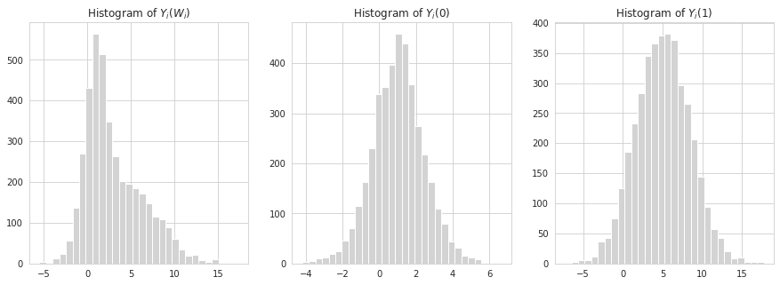

```python
plt.figure(figsize = (15,5))
plt.subplot(131)
plt.hist(Yi_train,bins = 30, color = "lightgrey")
plt.title("Histogram of $Y_i(W_i)$")
plt.subplot(132)
plt.hist(Y0_train,bins = 30, color = "lightgrey")
plt.title("Histogram of $Y_i(0)$")
plt.subplot(133)
plt.hist(Y1_train,bins = 30, color = "lightgrey")
plt.title("Histogram of $Y_i(1)$")
```

```
[-0.72820706 -1.47569508 -1.7427602   1.17488743  1.65302154  0.27001527]
{'mX0': 1.0, 'mX1': 1.5695361795205853, 'sigma00': 1.0, 'sigma11': 1.0789582530334885, 'sigma01': 0.9}
```

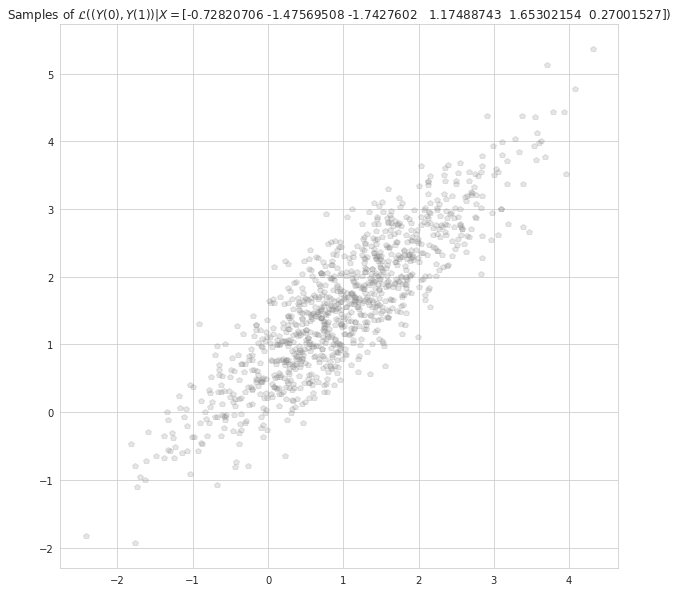

```python
IndexTest = 10
Y0x,Y1x = sampleY(X[IndexTest],1000)
plt.figure(figsize = (10,10))
plt.plot(Y0x,Y1x,"p", color = "grey",alpha = 0.2)
InfoTest = getInfoY(X[IndexTest])
plt.title("Samples of $\mathcal{L}((Y(0),Y(1)) | X =$"+str(X[IndexTest])+"$)$")
print(X[IndexTest])
print(InfoTest)
```

```python
np.cov(Y0x,Y1x)
```

```
array([[1.05382309, 0.93168275],
       [0.93168275, 1.08420357]])
```

# Meta-learners for conditional distribution estimation.

## Notation

A model trained by the training data $(\mathbf{X}_i,Y_i;1\leq i \leq N)$ is denoted by $$ \mathcal{M}_{\left\{\mathbf{X}_i\sim Y_i \;|\; i\in [N]\right\}}. $$ The associated prediction at point $\mathbf{x}$ is denoted by $$ \mathbf{Pred}\left(\mathbf{x} \;|\; \mathcal{M}_{\left\{\mathbf{X}_i\sim Y_i \;|\; i\in [N]\right\}} \right). $$ This notation is more compatible with the models in the Bayesian nonparametrics context, emphasizing the randomness brought by the model itself. When the underlying model is Random Forests-based, we replace $\mathcal{M}$ by $\mathcal{T}$. Below we list the construction of T-, S- and X-learners.

### T-learners:

Divided by two subgroups w.r.t. $W_i$, we consider the estimator $\hat{\mu}_{\omega}^T$ of $\mu_{\omega}$ defined as follows: $$ \hat{\mu}_{\omega}^T(\mathbf{x}) :=\mathbf{Pred}\left(\mathbf{x} \;|\; \mathcal{M}_{\left\{\mathbf{X}_i\sim Y_i \;|\; W_i = \omega,\;i\in [N]\right\}}\right). $$ Then, the estimator $\hat{\tau}^T$ of $\tau$ is defined by $$ \hat{\tau}^T(\mathbf{x}) = \hat{\mu}_{1}^T(\mathbf{x}) - \hat{\mu}_{0}^T(\mathbf{x}). $$

### S-learners:

Without specifying the role of $W_i$, the estimator $\hat{\mu}_{\omega}$ of $\mu_{\omega}$ defined as follows: $$ \hat{\mu}_{\omega}^S(\mathbf{x}) := \mathbf{Pred}\left((\mathbf{x},\omega) \;|\; \mathcal{M}_{\left\{(\mathbf{X}_i,W_i)\sim Y_i \;|\; i\in [N]\right\}}\right). $$ Then, the estimator $\hat{\tau}^S$ of $\tau$ is defined by $$ \hat{\tau}^S(\mathbf{x}) = \hat{\mu}_{1}^S(\mathbf{x}) - \hat{\mu}_{0}^S(\mathbf{x}). $$

### X-learners:

By estimating the "missing" potential outcomes with the same spirit of T-learners, we define

$$ \hat{\tau}_{1}^X(\mathbf{x}) := \mathbf{Pred}\left(\mathbf{x} \;|\; \mathcal{M}_{\left\{\mathbf{X}_i \sim Y_i - \hat{\mu}_0^T(\mathbf{X}_i) \;|\; W_i = 1,\;i\in [N]\right\}}\right), $$

and

$$ \hat{\tau}_{0}^X(\mathbf{x}) :=\mathbf{Pred}\left(\mathbf{x} \;|\; \mathcal{M}_{\left\{\mathbf{X}_i \sim \hat{\mu}_1^T(\mathbf{X}_i) - Y_i \;|\; W_i = 0,\;i\in [N]\right\}}\right). $$

The final estimator $\hat{\tau}^X$ of $\tau$ is constructed by taking the convex combination of the two estimators defined above, that is

$$ \hat{\tau}^X(\mathbf{x}) := g(\mathbf{x})\hat{\tau}_1^X(\mathbf{x}) + (1-g(\mathbf{x}))\hat{\tau}_0^X(\mathbf{x}). $$

For the choice of $g(\mathbf{x})$, one may consider the estimator of the propensity score $\hat{e}(\mathbf{x})$, or one can simply take $0$ or $1$ according to the data.

### Stage 1: parametric models

The only ingredient required for conditional distribution estimation is the conditional mean estimator $\hat{\mu}_0^T$ and $\hat{\mu}_1^T$. However, the estimator for the covariance matrix is of taste as X-learners.

$$ \hat{\sigma}_{00}(\mathbf{x}) := \mathbf{Pred}\left(\mathbf{x}\;|\; \mathcal{M}_{\left\{\mathbf{X}_i \sim Y_i^2 \;|\; W_i = 0,\;i\in [N]\right\}}\right) - \hat{\mu}_0^T(\mathbf{x})^2 , $$

and

$$ \hat{\sigma}_{11}(\mathbf{x}) := \mathbf{Pred}\left(\mathbf{x}\;|\; \mathcal{M}_{\left\{\mathbf{X}_i \sim Y_i^2 \;|\; W_i = 1,\;i\in [N]\right\}}\right) - \hat{\mu}_1^T(\mathbf{x})^2 , $$

as well as

$$ \begin{aligned} & \hat{\sigma}_{01}(\mathbf{x}) \\ :=& g(\mathbf{x}) \mathbf{Pred}\left(\mathbf{x}\;|\; \mathcal{M}_{\left\{\mathbf{X}_i \sim \hat{\mu}_0^T(\mathbf{X}_i)Y_i \;|\; W_i = 1,\;i\in [N]\right\}}\right) \\& +(1-g(\mathbf{x})) \mathbf{Pred}\left(\mathbf{x}\;|\; \mathcal{M}_{\left\{\mathbf{X}_i \sim Y_i \hat{\mu}_1^T(\mathbf{X}_i) \;|\; W_i = 0,\;i\in [N]\right\}}\right) - \hat{\mu}_0^T(\mathbf{x}) \hat{\mu}_1^T(\mathbf{x}) , \end{aligned} $$

where $g(\mathbf{x})$ can be any $[0,1]$-valued function, which can be chosen as an estimator of the propensity score. For simplicity, we take $g(\mathbf{x})\equiv 1/2$.

```python
# divide training data according to treatment assignment.

W_multi = np.transpose(np.array([W_train for i in range(d)])).reshape(N_train,d)

X_train_treated = np.extract(W_multi,X_train)
X_train_treated = np.transpose(X_train_treated).reshape(np.sum(W_train),d)
Yi_train_treated = np.extract(W_train,Yi_train)

X_train_control = np.extract(1-W_multi,X_train)
X_train_control = np.transpose(X_train_control).reshape(N_train - np.sum(W_train),d)
Yi_train_control = np.extract(1-W_train,Yi_train)

# test data

W_test_multi = np.transpose(np.array([W_test for i in range(d)])).reshape(N_test,d)
X_test_treated = np.extract(W_test_multi,X_test)
X_test_treated = np.transpose(X_test_treated).reshape(np.sum(W_test),d)
Yi_test_treated = np.extract(W_test,Yi_test)

X_test_control = np.extract(1-W_test_multi,X_test)
X_test_control = np.transpose(X_test_control).reshape(N_test - np.sum(W_test),d)
Yi_test_control = np.extract(1-W_test,Yi_test)
```

```python
from sklearn.ensemble import RandomForestRegressor
from sklearn.ensemble import AdaBoostRegressor
from xgboost import XGBRegressor
from sklearn.metrics import mean_squared_error
#mu0T_hat = RandomForestRegressor(n_estimators = 100, min_samples_split=2)
#mu0T_hat = XGBRegressor(learning_rate = 0.1,
#                        objective = "reg:squarederror",
#                        n_estimators = 30)
mu0T_hat = AdaBoostRegressor(learning_rate = 0.1, n_estimators = 10)
mu0T_hat.fit(X_train_control, Yi_train_control)
#mu1T_hat = RandomForestRegressor(n_estimators = 100, min_samples_split=2)
#mu1T_hat = AdaBoostRegressor(learning_rate = 0.1, n_estimators = 10)
mu1T_hat = XGBRegressor(learning_rate = 0.1,
                        objective = "reg:squarederror",
                        n_estimators = 30)
mu1T_hat.fit(X_train_treated, Yi_train_treated)
```

```
XGBRegressor(base_score=0.5, booster='gbtree', colsample_bylevel=1,
             colsample_bynode=1, colsample_bytree=1, gamma=0,
             importance_type='gain', learning_rate=0.1, max_delta_step=0,
             max_depth=3, min_child_weight=1, missing=None, n_estimators=30,
             n_jobs=1, nthread=None, objective='reg:squarederror',
             random_state=0, reg_alpha=0, reg_lambda=1, scale_pos_weight=1,
             seed=None, silent=None, subsample=1, verbosity=1)
```

```python
## other choices for base learners
# from sklearn.linear_model import LinearRegression
# from sklearn.ensemble import AdaBoostRegressor
# mu0T_hat = AdaBoostRegressor()
# mu0T_hat.fit(X_train_control, Yi_train_control)
# mu1T_hat = AdaBoostRegressor()
# mu1T_hat.fit(X_train_treated, Yi_train_treated)
```

## Illustration of the estimation of $\hat{\mu}_0^T$ and $\hat{\mu}_1^T$

We choose randomly 100 sample points respectively in treated and control group in test data, and compare the prediction of $Y(0)$ (resp. $Y(1)$) with the reference values.

### Additional Info:

#### Evaluation

To evaluate the quality of prediction, we consider:

- *RMSE*: root-mean-square error $$ \mathrm{RMSE} := \sqrt{\sum_{i=1}^N (\mathrm{Pred_i} - \mathrm{Ref}_i)^2}. $$
- *Score*: coefficient of determination, defined by $$ \mathrm{score} := 1 - \frac{R_{res}}{R_{tot}}. $$

#### Visualization

To illustrate the quality of estimation, we first draw a subsample of size 100 in the test date, then we plot repectively the predicitions and the reference values.

#### Base-learners

For the choice of the base-learners, we mainly consider:

##### Forests-based

- Random Forests:

https://scikit-learn.org/stable/modules/generated/sklearn.ensemble.RandomForestRegressor.html

- Mondrian Forests:

https://scikit-garden.github.io/examples/MondrianTreeRegressor/

##### Boosting-based

- AdaBoost:

https://scikit-learn.org/stable/modules/generated/sklearn.ensemble.AdaBoostRegressor.html

- XGBoost:

https://xgboost.readthedocs.io/en/latest/tutorials/model.html

for parameters: https://xgboost.readthedocs.io/en/latest/parameter.html

```
size of treated group in training data: 1966, 49.1%.
Score on the test dataset: 0.9809638846149588
RMSE on the test dataset: 0.4267775054935421
```

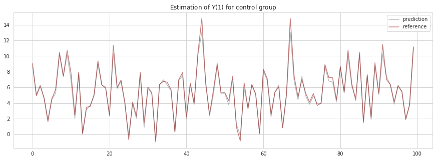

```python
plt.figure(figsize=(15,5))
RandomSubgroup = np.random.choice(range(np.sum(1-W_test)),100)
plt.plot(mu1T_hat.predict(X_test_control[RandomSubgroup]),color="grey",alpha=0.5,label="prediction")
plt.plot(
    np.apply_along_axis(mX1,1,X_test[np.extract(1-W_test,range(N_test))[RandomSubgroup]]),
    color="darkred",alpha=0.5,label="reference")
plt.title("Estimation of $Y(1)$ for control group")
plt.legend()
print("size of treated group in training data: {}, {:.1%}.".format(sum(W_train),sum(W_train)/N_train))
print("Score on the test dataset:",mu1T_hat.score(X_test, np.apply_along_axis(mX1,1,X_test)))
print("RMSE on the test dataset:", np.sqrt(mean_squared_error(np.apply_along_axis(mX1,1,X_test),mu1T_hat.predict(X_test))))
```

```
size of treated group in training data: 2034, 50.8%.
Score on the test dataset: 0.0
RMSE on the test dataset: 0.04314684780702415
```

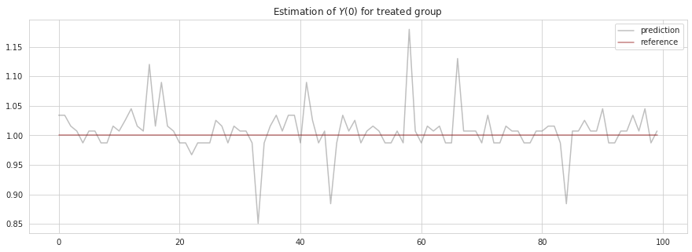

```python
plt.figure(figsize=(15,5))
RandomSubgroup = np.random.choice(range(np.sum(W_test)),100)
plt.plot(mu0T_hat.predict(X_test_treated[RandomSubgroup]),color="grey",alpha=0.5,label="prediction")
plt.plot(
    np.apply_along_axis(mX0,1,X_test[np.extract(W_test,range(N_test))[RandomSubgroup]]),
    color="darkred",alpha=0.5,label="reference")
plt.title("Estimation of $Y(0)$ for treated group")
plt.legend()
print("size of treated group in training data: {}, {:.1%}.".format(sum(1-W_train),sum(1-W_train)/N_train))
print("Score on the test dataset:", mu0T_hat.score(X_test, np.apply_along_axis(mX0,1,X_test)))
print("RMSE on the test dataset:", np.sqrt(mean_squared_error(np.apply_along_axis(mX0,1,X_test),mu0T_hat.predict(X_test))))
```

## Covariance matrix estimators

```python
from sklearn.metrics import r2_score


#mu00_hat = RandomForestRegressor(n_estimators = 100, min_samples_split=2)
#mu00_hat = AdaBoostRegressor(learning_rate = 0.1, n_estimators = 20)
mu00_hat = XGBRegressor(learning_rate = 0.1,
                        n_estimators = 50,
                        objective = "reg:squarederror",
                       gamma=2.)
mu00_hat.fit(X_train_control, Yi_train_control**2)
def sigma00_hat(x):
    return mu00_hat.predict(x) - mu0T_hat.predict(x)**2
#mu11_hat = RandomForestRegressor(n_estimators = 100, min_samples_split=2)
#mu11_hat = AdaBoostRegressor(learning_rate = 0.1, n_estimators = 50)
mu11_hat = XGBRegressor(learning_rate = 0.1,
                        booster = "gbtree",
                        objective = "reg:squarederror",
                        n_estimators = 20,
                       gamma=1.,
                       subsample = 1.,
                       reg_lambda = 1.)
mu11_hat.fit(X_train_treated, Yi_train_treated**2)
def sigma11_hat(x):
    return mu11_hat.predict(x) - mu1T_hat.predict(x)**2
```

```python
mu01_hat_0 = RandomForestRegressor(n_estimators = 100, min_samples_split=5)
#mu01_hat_0.fit(X_train_control,Yi_train_control*mu1T_hat.predict(X_train_control))
mu01_hat_0.fit(X_train_control,Yi_train_control*mu1T_hat.predict(X_train_control))
mu01_hat_1 = RandomForestRegressor(n_estimators = 100, min_samples_split=5)
#mu01_hat_1.fit(X_train_treated,Yi_train_treated*mu0T_hat.predict(X_train_treated))
mu01_hat_1.fit(X_train_treated,Yi_train_treated*mu0T_hat.predict(X_train_treated))
def sigma01_hat(x):
    #return mu01_hat_0.predict(x)*(1-np.apply_along_axis(e_func, 1, x)) + mu01_hat_1.predict(x)*np.apply_along_axis(e_func, 1, x)
    return mu01_hat_0.predict(x)*.5 + mu01_hat_1.predict(x)*.5 - mu0T_hat.predict(x)*mu1T_hat.predict(x)
```

```
score: -0.17280967980716433
RMSE on the test dataset: 0.80172318115857
```

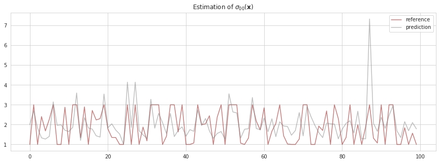

```python
plt.figure(figsize = (15,5))
RandomSubgroup = np.random.choice(range(N_test),100)
plt.plot(np.apply_along_axis(sigma00, 1, X_test[RandomSubgroup]),color="darkred",alpha=0.5,label="reference")
plt.plot(sigma00_hat(X_test[RandomSubgroup]),color="grey",alpha=0.5,label="prediction")
plt.title("Estimation of $\sigma_{00}(\mathbf{x})$")
plt.legend()
print("score:", r2_score(sigma00_hat(X_test),np.apply_along_axis(sigma00, 1, X_test)))
print("RMSE on the test dataset:", np.sqrt(mean_squared_error(np.apply_along_axis(sigma00,1,X_test),sigma00_hat(X_test))))
```

```
score: -0.33208254994340014
RMSE on the test dataset: 3.320856544220381
```

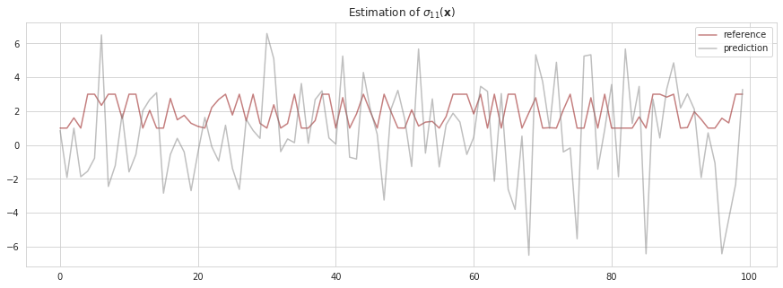

```python
plt.figure(figsize = (15,5))
RandomSubgroup = np.random.choice(range(N_test),100)
plt.plot(np.apply_along_axis(sigma11, 1, X_test[RandomSubgroup]),color="darkred",alpha=0.5,label="reference")
plt.plot(sigma11_hat(X_test[RandomSubgroup]),color="grey",alpha=0.5,label="prediction")
plt.title("Estimation of $\sigma_{11}(\mathbf{x})$")
plt.legend()
print("score:", r2_score(sigma11_hat(X_test),np.apply_along_axis(sigma11, 1, X_test)))
print("RMSE on the test dataset:", np.sqrt(mean_squared_error(np.apply_along_axis(sigma11,1,X_test),sigma11_hat(X_test))))
```

```
score: -0.5913874033780999
RMSE on the test dataset: 1.3488601456961298
```

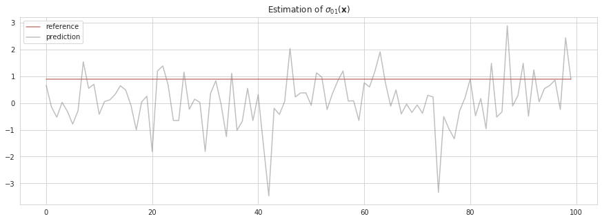

```python
plt.figure(figsize = (15,5))
RandomSubgroup = np.random.choice(range(N_test),100)
plt.plot(np.apply_along_axis(sigma01, 1, X_test[RandomSubgroup]),color="darkred",alpha=0.5,label="reference")
plt.plot(sigma01_hat(X_test[RandomSubgroup]),color="grey",alpha=0.5,label="prediction")
plt.title("Estimation of $\sigma_{01}(\mathbf{x})$")
plt.legend()
print("score:", r2_score(sigma01_hat(X_test),np.apply_along_axis(sigma01, 1, X_test)))
print("RMSE on the test dataset:", np.sqrt(mean_squared_error(np.apply_along_axis(sigma01,1,X_test),sigma01_hat(X_test))))
```

## Comments

Any ideas on how to construct covariance estimators in this Gaussian case?

# Test with Mondrian Forests

```python
from skgarden import MondrianForestRegressor, MondrianTreeRegressor

mu0T_hat = MondrianForestRegressor(n_estimators = 100, min_samples_split=2)
mu0T_hat.fit(X_train_control, Yi_train_control)

mu1T_hat = MondrianForestRegressor(n_estimators = 100, min_samples_split=2)
mu1T_hat.fit(X_train_treated, Yi_train_treated)
```

```
MondrianForestRegressor(bootstrap=False, max_depth=None, min_samples_split=2,
                        n_estimators=100, n_jobs=1, random_state=None,
                        verbose=0)
```

```
size of treated group in training data: 1966, 49.1%.
0.8911961289343913
```

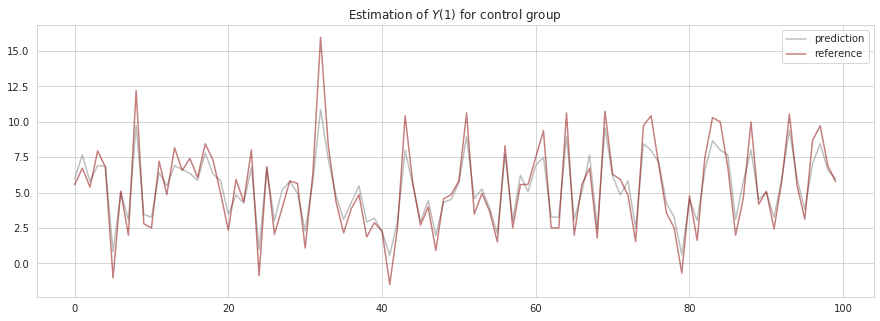

```python
plt.figure(figsize=(15,5))
RandomSubgroup = np.random.choice(range(np.sum(1-W_test)),100)
plt.plot(mu1T_hat.predict(X_test_control[RandomSubgroup]),color="grey",alpha=0.5,label="prediction")
plt.plot(
    np.apply_along_axis(mX1,1,X_test[np.extract(1-W_test,range(N_test))[RandomSubgroup]]),
    color="darkred",alpha=0.5,label="reference")
plt.title("Estimation of $Y(1)$ for control group")
plt.legend()
print("size of treated group in training data: {}, {:.1%}.".format(sum(W_train),sum(W_train)/N_train))
print(mu1T_hat.score(X_test, np.apply_along_axis(mX1,1,X_test)))
```

```
size of treated group in training data: 2034, 50.8%.
Score on the test dataset: 0.0
```

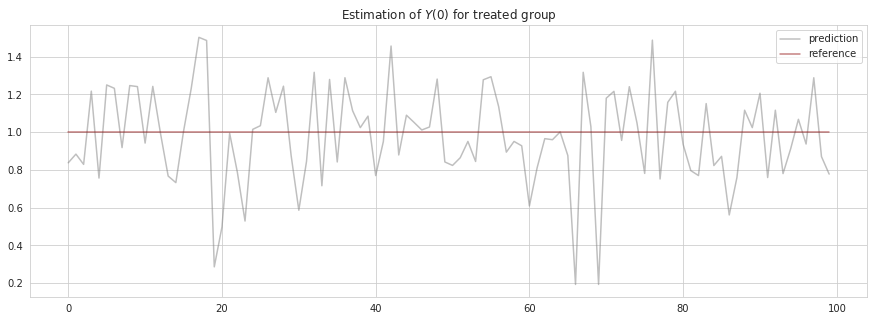

```python
plt.figure(figsize=(15,5))
RandomSubgroup = np.random.choice(range(np.sum(W_test)),100)
plt.plot(mu0T_hat.predict(X_test_treated[RandomSubgroup]),color="grey",alpha=0.5,label="prediction")
plt.plot(
    np.apply_along_axis(mX0,1,X_test[np.extract(W_test,range(N_test))[RandomSubgroup]]),
    color="darkred",alpha=0.5,label="reference")
plt.title("Estimation of $Y(0)$ for treated group")
plt.legend()
print("size of treated group in training data: {}, {:.1%}.".format(sum(1-W_train),sum(1-W_train)/N_train))
print("Score on the test dataset:", mu0T_hat.score(X_test, np.apply_along_axis(mX0,1,X_test)))
```

# Forest-based conditional distribution estimation

```python
from sklearn.tree import DecisionTreeRegressor
```

```python
def samplerY0x(x,n_estimators,N):
    Y0x_empirical = np.zeros(n_estimators)
    for i in range(n_estimators):
        nu0T_hat = DecisionTreeRegressor()
        #nu0T_hat = RandomForestRegressor(n_estimators=1, bootstrap=False)
        nu0T_hat = MondrianForestRegressor(n_estimators=1, bootstrap=True)
        nu0T_hat.fit(X_train_control, Yi_train_control)

        # bootstrap manually
        # BootstrapSize = 10000
        # N_train_0 = sum(1-W_train)
        # nu0T_hat.fit(X_train_control[np.random.choice(range(N_train_0),BootstrapSize)], Yi_train_control[np.random.choice(range(N_train_0),BootstrapSize)])
        Y0x_empirical[i] =nu0T_hat.predict(x.reshape(1,d))
    Y0x_sample = np.zeros(N)
    # for i in range(N):
    #     m = np.random.choice(Y0x_empirical,1)
    #     Y0x_sample[i] = np.random.normal(m,1.5,1)
    #
    # return Y0x_sample
    return np.random.choice(Y0x_empirical,N)

def samplerY1x(x,n_estimators,N):
    Y1x_empirical = np.zeros(n_estimators)
    for i in range(n_estimators):
        nu1T_hat = MondrianForestRegressor(n_estimators = 1, bootstrap=True)
        nu1T_hat.fit(X_train_treated, Yi_train_treated)
        Y1x_empirical[i] =nu1T_hat.predict(x.reshape(1,d))
    return np.random.choice(Y1x_empirical,N)
```

```python
TestIndex = 15
y0 = samplerY0x(X_test[TestIndex],20,1000)
y1 = samplerY1x(X_test[TestIndex],20,1000)
```

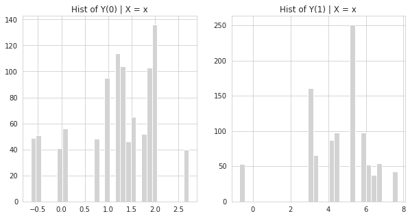

```python
plt.figure(figsize = (10,5))
plt.subplot(121)
plt.hist(y0,bins =30, color="lightgrey")
plt.title("Hist of Y(0) | X = x")
plt.subplot(122)
plt.hist(y1,bins =30, color="lightgrey")
plt.title("Hist of Y(1) | X = x")
```

```python
getInfoY(X_test[TestIndex])
```

```
{'mX0': 1.0,
 'mX1': 4.892827337359855,
 'sigma00': 1.0,
 'sigma11': 3.0,
 'sigma01': 0.9}
```

```python
np.mean(y0)
```

```
1.1836145285563544
```

```python
np.var(y0)
```

```
0.7183969863114369
```

```python
np.mean(y1)
```

```
4.642889865338803
```

```python
np.var(y1)
```

```
3.136919068070546
```

```python
gc.collect()
```

```
12445
```

# Drafts

```python
X = np.random.uniform(0,1,(5000,5))
#Y = np.random.normal(0,1.,5000) +np.sin(X[:,1]+X[:,3]) +X[:,2]**2
Y = np.random.normal(0,1.,5000) + 1
```

```python
from sklearn.ensemble import AdaBoostRegressor
from xgboost import XGBRegressor
reg = AdaBoostRegressor(learning_rate = 0.1, n_estimators = 10)
#reg = XGBRegressor(n_estimators = 20)
#reg = RandomForestRegressor(n_estimators = 100)
reg.fit(X[0:4000,:],Y[0:4000])
```

```
AdaBoostRegressor(base_estimator=None, learning_rate=0.1, loss='linear',
                  n_estimators=10, random_state=None)
```

```python
from sklearn.metrics import mean_squared_error
np.sqrt(mean_squared_error(np.zeros(1000)+1.,reg.predict(X[4000:])))
```

```
0.06853218806163983
```

```python
np.mean(reg.predict(X[4000:]))
```

```
1.0161601788924157
```

```python
np.mean(Y[4000:])
```

```
1.019043940319142
```